# Covid-19 in Belgium

Huy Nguyen

31/07/2021

# Introduction

We have developed a small web application that shows the number of Covid-19 hospitalisations by provinces during the period of 2020-03-15 to 2021-07-27.

The data are provided by Sciensano, the Belgian institute for health, and are available at https://epistat.wiv-isp.be/covid/ under the section “Datasets/Hospitalisations by date and provinces”.

The web application is hosted at  
https://huy-s-nguyen.shinyapps.io/Covid-19-in-Belgium-2021/

The code of the web application, ui.R and server.R, can be found at  
https://github.com/huy-seraphim-nguyen/Shiny-Application/

# The application

The application can be ran online by visiting the URL  
https://huy-s-nguyen.shinyapps.io/Covid-19-in-Belgium-2021/

The application presents 2 panels:

- The left panel provides the selection of a province, using a drop down list menu.
- The right panel presents a barplot of the Total number of hospitalisations by provinces.  
  It also shows the number of hospitalisations of the province you selected in the left panel.

# Example application output (right panel)

An example of the right panel when user selects “Brussels” as province.

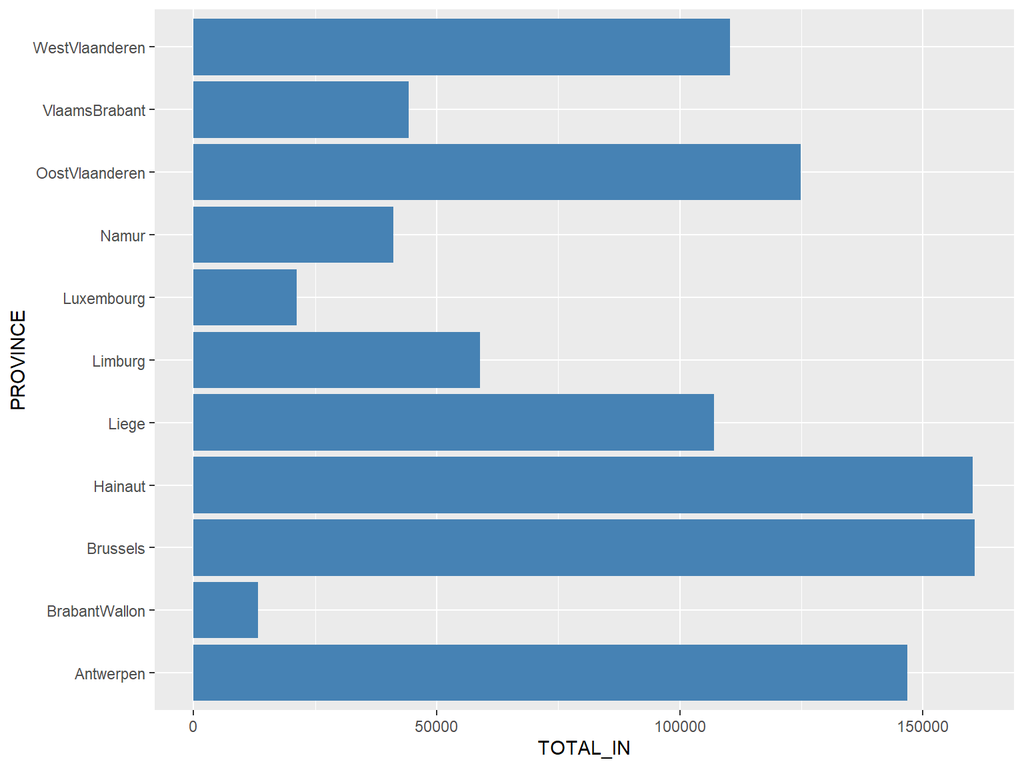

Total hospitalisations in Brussels : 160697

# Thank you for your attention